# Analyzing the nutrition content of common foods

## Visualizing Data

Let's visualize the data by creating a word cloud of the names of the products which make it through sanitization:

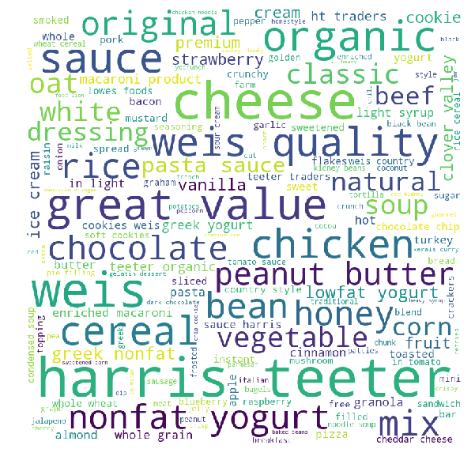

```python
from matplotlib import pyplot

# Taken from https://www.geeksforgeeks.org/generating-word-cloud-python/
from wordcloud import WordCloud, STOPWORDS
words = ''
stopwords = set(STOPWORDS)
# iterate through the csv file
for val in small_products['long_name']:

    # typecaste each val to string
    val = str(val)

    # split the value
    tokens = val.split()

    # Converts each token into lowercase
    for i in range(len(tokens)):
        tokens[i] = tokens[i].lower()

    words += " ".join(tokens)+" "

wordcloud = WordCloud(width = 800, height = 800,
                background_color ='white',
                stopwords = stopwords,
                min_font_size = 10).generate(words)

# plot the WordCloud image
pyplot.figure(figsize = (8, 8), facecolor = None)
pyplot.imshow(wordcloud)
pyplot.axis("off")
pyplot.tight_layout(pad = 0)

pyplot.show()
```

## Process Data

In order to analyze the nutrition content of these foods and compare them against each other, we will need to create a new database which organizes the data into one row for each food, with all of its nutrition information alongside it

```python
%%timeit

processed_data = pandas.DataFrame(columns=nutrients.Nutrient_name.unique())
processed_data['Identifier'] = small_products['NDB_Number']
processed_data['Name'] = small_products['long_name']
for row in processed_data.iterrows():
    index, data = row  # data is a Series object containing the row (could hae just done for index, row in..)
    for col in data.keys()[:-2]: # omit the last two rows (Identifier and Name)
        nutrient_data = small_nutrients[(small_nutrients.NDB_No == data.Identifier) & (small_nutrients.Nutrient_name == col)]
        if nutrient_data.empty:
            data[col] = float('NaN')
        else:
            data[col] = nutrient_data.Output_value.iloc[0]
    processed_data.iloc[index] = data
    break #Don't run the full loop, takes too long!
```

[output not shown]

### Speeding up our processing

This is very slow! Let's try to speed it up. Pandas comes with a built-in apply() method which works much faster than iteration using iterrows(), which is incidentally already about twice as fast as manual iteration using iloc[i++]

### Further Reading

This resource https://towardsdatascience.com/how-to-make-your-pandas-loop-71-803-times-faster-805030df4f06 explains how this speedup takes place and suggests even faster methods such as Numpy vectorization. However, it's not clear how to extend the Numpy vectorization method to work on two tables instead of just one. So for now, we'll stick with this.

```python
desired_columns = nutrients_to_analyze

processed_data = pandas.DataFrame(columns=desired_columns)
processed_data['Identifier'] = small_products['NDB_Number']
processed_data['Name'] = small_products['long_name']

def process(identifier,col_name):
    nutrient_data = small_nutrients[(small_nutrients.NDB_No == identifier) & (small_nutrients.Nutrient_name == col_name)]
    if nutrient_data.empty:
        return float('NaN')
    return nutrient_data.Output_value.iloc[0]

for col_name in desired_columns:
    processed_data[col_name] = processed_data.apply(lambda row:process(row.Identifier,col_name), axis=1)
    print(col_name)
```

[output not shown]

```python
processed_data = processed_data.dropna()
processed_data.head()
```

|  | Energy | Protein | Total lipid (fat) | Cholesterol | Identifier | Name |
| --- | --- | --- | --- | --- | --- | --- |
| 1001 | 857.0 | 0.00 | 100.00 | 0.0 | 45004003 | REFINED COCONUT OIL |
| 1002 | 433.0 | 6.67 | 20.00 | 0.0 | 45004004 | COVER VALLEY, SNACK CRACKERS, CHICKEN |
| 1003 | 400.0 | 10.00 | 13.33 | 0.0 | 45004005 | CLOVER VALLEY, PITA CHIPS, GARLIC & CHIVE |
| 1004 | 419.0 | 6.45 | 11.29 | 0.0 | 45004007 | CINNAMON GRAHAM CRACKERS |
| 1005 | 433.0 | 6.67 | 11.67 | 17.0 | 45004008 | JALAPENO CHEDDAR CORNBREAD CRACKERS |

We can plot this data to find trends:

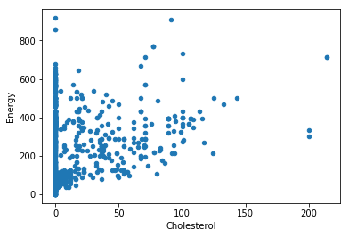

```python
processed_data.plot(kind='scatter', x='Cholesterol', y='Energy')
```

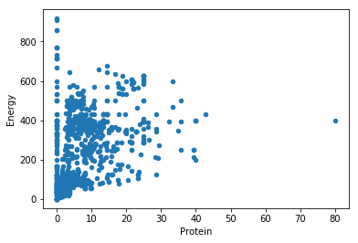

```python
processed_data.plot(kind='scatter', x='Protein', y='Energy')
```

## Clustering data with k-means

In order to answer our questions from earlier, we use k-means to cluster the data into groups. This algorithm works by choosing k random points and organizing data based on their distance to those points, then resetting the k means to be the centroids of the groups and iterating this process until convergence.

To implement k-means on our data, we will make use of sklearn's built in unsupervised learning methods.

### Futher Reading

For more information about this topic, see https://www.techopedia.com/definition/32057/k-means-clustering. Documentation of sklearn's other Kmeans methods can be found here: https://scikit-learn.org/stable/modules/generated/sklearn.cluster.KMeans.html.

```python
from sklearn.preprocessing import StandardScaler, MinMaxScaler
from sklearn.mixture import GaussianMixture

# k - means
k = 7
model = GaussianMixture(n_components=k,
                        covariance_type="full",
                        random_state=1,
                        n_init=1,
                        max_iter=200,
                        init_params="kmeans")
X_train = processed_data[desired_columns].values
model.fit(X_train)
print("Model converged: " + str(model.converged_))
processed_data["cluster"] = model.predict(X_train)
```

```
Model converged: True
```

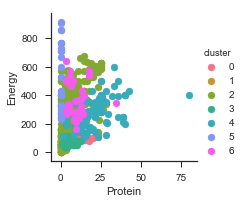

```python
import seaborn
from  matplotlib import pyplot
seaborn.set(style='ticks')
fg = seaborn.FacetGrid(data=processed_data, hue='cluster') #hue_order=_genders, aspect=1.61)
fg.map(pyplot.scatter, 'Protein', 'Energy').add_legend()
```

Now that our data is clustered, we can look at the data in each cluster to determine what patterns our unsupervised learning method has found in the data.

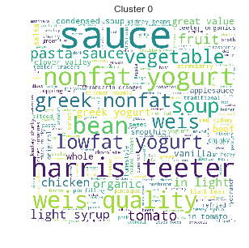

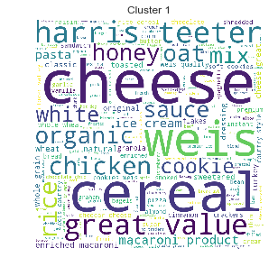

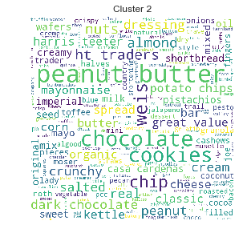

```python
# Taken from https://www.geeksforgeeks.org/generating-word-cloud-python/
from wordcloud import WordCloud, STOPWORDS
for cluster in range(k):
    words = ''
    stopwords = set(STOPWORDS)
    # iterate through the csv file
    for val in processed_data[processed_data.cluster == cluster]['Name']:

        # typecaste each val to string
        val = str(val)

        # split the value
        tokens = val.split()

        # Converts each token into lowercase
        for i in range(len(tokens)):
            tokens[i] = tokens[i].lower()

        words += " ".join(tokens)+" "

    wordcloud = WordCloud(width = 800, height = 800,
                    background_color ='white',
                    stopwords = stopwords,
                    min_font_size = 10).generate(words)

    # plot the WordCloud image
    pyplot.figure(figsize = (4, 4), facecolor = None)
    pyplot.imshow(wordcloud)
    pyplot.axis("off")
    pyplot.tight_layout(pad = 0)
    pyplot.title('Cluster ' + str(cluster))

    pyplot.show()
```

[output not shown]

To check that our clustering has produced useful results, we can look at the level of correlation between cluster means. This gives us a measure of whether our clusters are producing groups of data with significant differences between them or not. Large correlation indicates that our groups have similar content, while low correlation indicates that our groups differ enough to be considered separate entities:

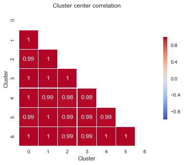

```python
import numpy as np
# https://www.kaggle.com/allunia/hidden-treasures-in-our-groceries
cluster_stats = pandas.DataFrame(data=model.means_)
seaborn.set(style="white")
corr = cluster_stats.transpose().corr()

mask = np.zeros_like(corr, dtype=np.bool)
mask[np.triu_indices_from(mask)] = True

f, ax = pyplot.subplots(figsize=(6, 6))
seaborn.heatmap(corr, mask=mask, cmap="coolwarm",
            vmin=-1, vmax=1, square=True, center=0,
            linewidths=.5, cbar_kws={"shrink": .5},
           annot=True)
ax.set_xlabel("Cluster")
ax.set_ylabel("Cluster")
ax.set_title("Cluster center correlation");
```

## Conclusion

We can see that our clusters have different types of food, and but some elements (such as cheese) appear in a variety of clusters, and the data is not strongly grouped. This agrees with our correlation analysis, which shows a high correlation between clusters. In conclusion, we have found that correlation analysis is a powerful tool in data science and can be applied to tell us important features of results of unsupervised learning methods which we would otherwise have to figure out ourselves.